# Learning R: Descriptives and Histograms

Michelle Chiu

Last updated on 2022-02-15

The following tutorial demonstrates how to do some basic data manipulation and plotting using survey data downloaded from the Pew Research Center. I originally created this to introduce undergraduates in the lab to R through fun visualizations of publicly available data.

*This demo is adapted from DataCamp’s [“Tidy Analysis of Pew Research Data Using R”](https://www.datacamp.com/community/tutorials/tidy-analysis-pew-research-data-r) and [R Tutorials](https://debyeeneuro.com/r-tutorials/) (Debbie Yee and Sara Weston).*

## Access the dataset

1. To access and download the dataset used in this demo, you will have to first [register for a Pew Research Center account](https://www.pewresearch.org/internet/datasets/). The registration process should be fairly quick and straightforward.
2. After you’ve successfully signed up for an account (received an email confirmation, etc.), navigate [here](https://www.pewresearch.org/internet/?post_type=dataset) to find a list of datasets grouped under *Internet and Technology* on the Pew site.
3. Scroll down to the dataset labeled **Jan. 3-10, 2018 - Core Trends Survey** and click on Download Dataset.

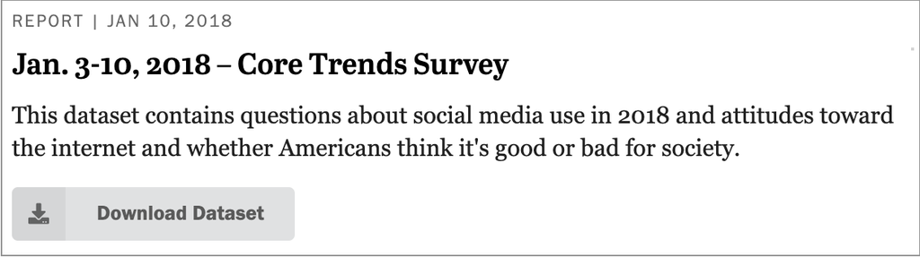

4. **Once download is complete**, you should see a zipped folder named “January 3-10, 2018 - Core Trends Survey” on your local computer (likely in your Downloads folder). Depending on how your computer is set up, you may need to unzip the folder to access its contents. The unzipped folder should contain five files.

   **In this demo, we will be using the following two files**:
   - *January 3-10, 2018 - Core Trends Survey - Questionnaire.docx*: A Word Doc copy of the administered survey. Akin to a *data dictionary* (See: [IBM Dictionary of Computing Terminology](https://www.ibm.com/ibm/history/documents/pdf/glossary.pdf)), this doc includes the abbreviated variable names used in our dataset alongside their respective questions and answer choices, which will be crucial in data interpretation.
   - *January 3-10, 2018 - Core Trends Survey - CSV.csv*: This CSV file is the raw dataset we will be working with.

## Code

### Load packages

```r
library(skimr)
library(psych)
library(tidyverse)
library(ggplot2)
```

### Load dataset

```r
# set working directory, if needed
# working directory should match your .RProj location
setwd("~/Downloads")

# load dataset
jan_core_trends_survey <-
  read.csv("January 3-10, 2018 - Core Trends Survey - CSV.csv")
```

### Pew dataset at a glance

For ease of viewing, I’ve hidden some of the text output below.

```r
# number of observations
nrow(jan_core_trends_survey)

# number of column variables
length(jan_core_trends_survey)

# check out the first 6 (default) rows of the data
head(jan_core_trends_survey)

# print first ten responses for age variable
head(jan_core_trends_survey$age, n = 10)

# skim function from skimr package prints summary stats
# get stats summary for age variable
skim(jan_core_trends_survey$age)

# we can also focus on specific stats
jan_core_trends_survey %>%
  skim() %>%
  focus(n_missing) %>% # only show # of obs missing per variable
  filter(n_missing > 0) # only show me variables with at least 1 missing
```

### Histogram of Age

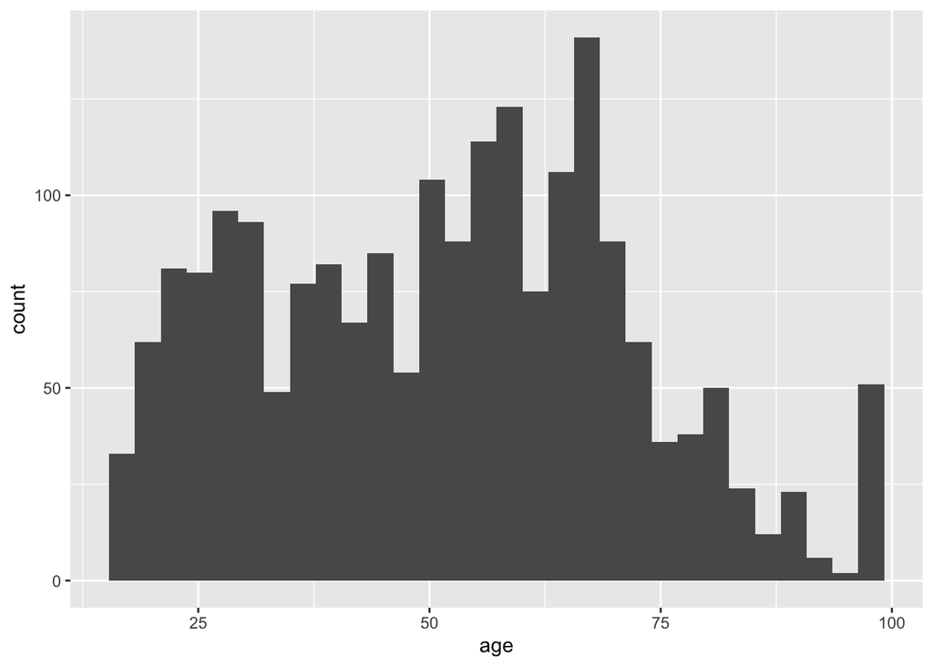

```r
# age distribution
ggplot(data = jan_core_trends_survey, aes(x = age)) +
  geom_histogram()
```

### Group data by category

#### Example. Age distribution by marital status

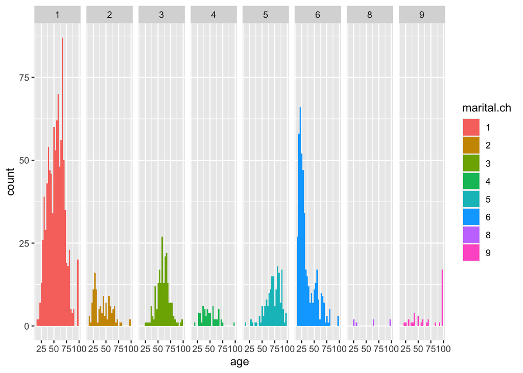

```r
# convert marital variable from numeric to character
jan_core_trends_survey$marital.ch <- as.character(jan_core_trends_survey$marital)

# plot
ggplot(data = jan_core_trends_survey, aes(x = age, fill = marital.ch)) +
  geom_histogram() +
  facet_grid(~ marital.ch)
```

### Filter data by category levels

#### Example 1. Age distribution by political party (excluding “No preference,” “Don’t know” or “Refused”)

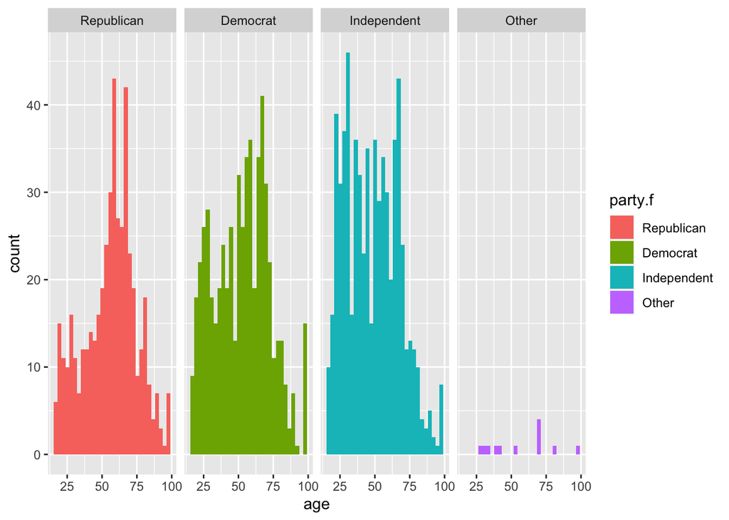

```r
# select relevant variables, then filter party variable
data_age_party <-
  jan_core_trends_survey %>%
  select(age, party) %>%
  filter(party==1 | party == 2 | party ==3 | party == 5)

# convert party to character
data_age_party$party.ch <- as.character(data_age_party$party)

# create factor for party variable, add meaningful labels for levels
data_age_party$party.f <- factor(data_age_party$party.ch,
                                 levels = c(1, 2, 3, 5),
                                 labels = c("Republican", "Democrat",
                                            "Independent", "Other"))

# plot
ggplot(data = data_age_party, aes(x = age, fill = party.f)) +
  geom_histogram() +
  facet_grid(~ party.f)
```

#### Example 2. Age distribution by employment status (excluding “Don’t know” or “Refused”)

```r
# filter employment variable
data_age_employment <-
  jan_core_trends_survey %>%
  select(age, emplnw) %>%
  filter(emplnw < 9)

# check filtering using describe function
# min and max should be 1 and 8, respectively
describe(data_age_employment$emplnw)
```

```
##    vars    n mean   sd median trimmed  mad min max range skew kurtosis   se
## X1    1 1979 2.35 1.49      2    2.13 1.48   1   8     7 1.08     0.99 0.03
```

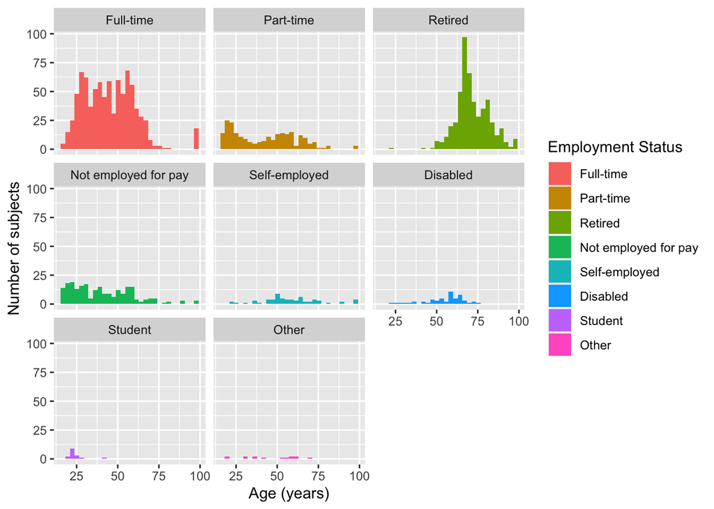

```r
# plot histogram for filtered dataset
# convert employment to character
data_age_employment$emplnw.ch <- as.character(data_age_employment$emplnw)

# create new factor variable with new level names for party
data_age_employment$emplnw.f <- factor(data_age_employment$emplnw.ch,
                                 levels = c(1, 2, 3, 4,
                                            5, 6, 7, 8),
                                 labels = c("Full-time", "Part-time",
                                            "Retired", "Not employed for pay",
                                            "Self-employed", "Disabled",
                                            "Student", "Other"))

# plot
ggplot(data = data_age_employment, aes(x = age, fill = emplnw.f)) +
  geom_histogram() +
  facet_wrap(~ emplnw.f) +
  # add label names for both axes and fill legend
  labs(x = "Age (years)", y = "Number of subjects") +
  guides(fill = guide_legend(title = "Employment Status"))
```